# Exercise: Markov Chain Monte Carlo

Intuition, Implementation, and Diagnostics

Author

Alexander Massey

Published

April 6, 2026

## 1 Background

In Bayesian inference, the posterior distribution is:

$$P(\theta \mid \text{data}) = \frac{P(\text{data} \mid \theta)\, P(\theta)}{P(\text{data})}$$

The denominator $P(\text{data}) = \int P(\text{data} \mid \theta)\, P(\theta)\, d\theta$ is a high-dimensional integral that is analytically intractable in most real models. **Markov Chain Monte Carlo (MCMC)** sidesteps this problem entirely: instead of computing the posterior analytically, we *simulate a random walk* through the parameter space that — in the long run — visits each region in proportion to its posterior probability.

The key insight is that the normalising constant $P(\text{data})$ **cancels** when we take ratios of posterior densities, which is exactly what MCMC algorithms exploit.

## 2 The Coypus Example

We will work throughout with a simple survival estimation problem. In a winter study, **19 out of 57 coypus** survived. We want to estimate the survival probability $\theta$.

- **Likelihood:** $y \mid \theta \sim \text{Binomial}(57,\, \theta)$
- **Prior:** $\theta \sim \text{Uniform}(0, 1)$ (a flat, non-informative prior)
- **Posterior:** $\theta \mid y \sim \text{Beta}(20, 39)$ (analytically available here — useful for checking)

Because this is a one-parameter model, the posterior is tractable. We use it to build intuition for MCMC before scaling to problems where the integral is unavailable.

## 3 Setting Up the Model in R

The three building blocks of any MCMC sampler are the **log-likelihood**, the **log-prior**, and the **log-posterior**. We work on the log scale throughout for numerical stability.

```r
# Coypus data
survived <- 19
released <- 57

# Log-likelihood: Binomial
loglikelihood <- function(x, p) {
  dbinom(x = x, size = released, prob = p, log = TRUE)
}

# Log-prior: Uniform(0, 1)
logprior <- function(p) {
  dunif(x = p, min = 0, max = 1, log = TRUE)
}

# Log-posterior (unnormalised — the denominator cancels later)
posterior <- function(x, p) {
  loglikelihood(x, p) + logprior(p)
}
```

**Note**

We never need to compute $P(\text{data})$ — it disappears when we take the **ratio** of posteriors at two candidate locations.

## 4 The Metropolis Algorithm

The Metropolis algorithm constructs a Markov chain whose stationary distribution equals the target posterior. At each step:

1. **Start** at any valid parameter value $\theta_0$.
2. **Propose** a candidate $\theta^* = \text{logit}^{-1}(\text{logit}(\theta_{t-1}) + \varepsilon)$, where $\varepsilon \sim \mathcal{N}(0, \sigma^2)$. Proposing on the logit scale keeps candidates inside $(0,1)$.
3. **Compute** the acceptance ratio $R = \frac{P(\theta^* \mid y)}{P(\theta_{t-1} \mid y)}$. Because $P(\text{data})$ is identical in numerator and denominator, it cancels — this is the magic.
4. **Accept** $\theta^*$ with probability $\min(R, 1)$; otherwise stay at $\theta_{t-1}$.
5. **Repeat** steps 2–4 for many iterations.

```r
# Proposal function: random walk on logit scale
move <- function(x, away = 0.2) {
  logitx         <- log(x / (1 - x))
  logit_candidate <- logitx + rnorm(1, 0, away)
  candidate      <- plogis(logit_candidate)
  return(candidate)
}

# Metropolis sampler
run_metropolis <- function(inits, steps, away = 0.2, seed = 1234) {
  set.seed(seed)
  theta.post    <- rep(NA, steps)
  theta.post[1] <- inits

  for (t in 2:steps) {
    theta_star <- move(theta.post[t - 1], away = away)

    pstar  <- posterior(survived, p = theta_star)
    pprev  <- posterior(survived, p = theta.post[t - 1])
    logR   <- pstar - pprev
    R      <- exp(logR)

    accept        <- rbinom(1, 1, prob = min(R, 1))
    theta.post[t] <- ifelse(accept == 1, theta_star, theta.post[t - 1])
  }
  return(theta.post)
}
```

## 5 Exercise 1 — Run the Chain and Inspect the Output

Run the Metropolis algorithm for **100 steps** starting at $\theta_0 = 0.5$.

```r
theta.post <- run_metropolis(inits = 0.5, steps = 100)

head(theta.post)
```

```
[1] 0.5000000 0.4399381 0.4399381 0.4577124 0.4577124 0.4577124
```

```r
tail(theta.post)
```

```
[1] 0.4145878 0.3772087 0.3772087 0.3860516 0.3898536 0.3624450
```

**Questions:**

1. What do you notice about consecutive values (e.g., the first six)? What does this tell you about the nature of MCMC samples?
2. Plot the trace (iteration vs. $\theta$). Does the chain appear to be exploring the posterior, or is it stuck?
3. Now increase `steps` to **5 000**. Add horizontal lines for the posterior mean and the MLE ($19/57 \approx 0.333$). What do you observe?

**TipHint 1a**

Repeated values are not a bug — they occur when a proposed candidate is **rejected** and the chain stays put. This is expected behaviour; the chain still converges.

**TipHint 1b — Trace plot code**

```r
plot(theta.post, type = "l",
     xlab = "Iteration", ylab = expression(theta),
     main = "Metropolis trace plot")
```

**TipHint 1c — Long run with reference lines**

```r
theta.long <- run_metropolis(inits = 0.5, steps = 5000)

plot(theta.long, type = "l",
     xlab = "Iteration", ylab = expression(theta))
abline(h = mean(theta.long), col = "darkgreen", lwd = 2, lty = 2)  # posterior mean
abline(h = 19/57,            col = "red",       lwd = 2, lty = 2)  # MLE
legend("topright",
       legend = c("Posterior mean", "MLE"),
       col    = c("darkgreen", "red"), lty = 2, lwd = 2)
```

For a model with a flat prior, the posterior mean and MLE should be nearly identical. Why?

## 6 Exercise 2 — Burn-in

The chain requires some iterations to reach its **stationary distribution**, regardless of where it started. This initial wandering phase is called **burn-in**, and those samples are discarded before analysis.

Run the chain for **1 000 steps** starting at $\theta_0 = 0.99$ — far from the true posterior mass.

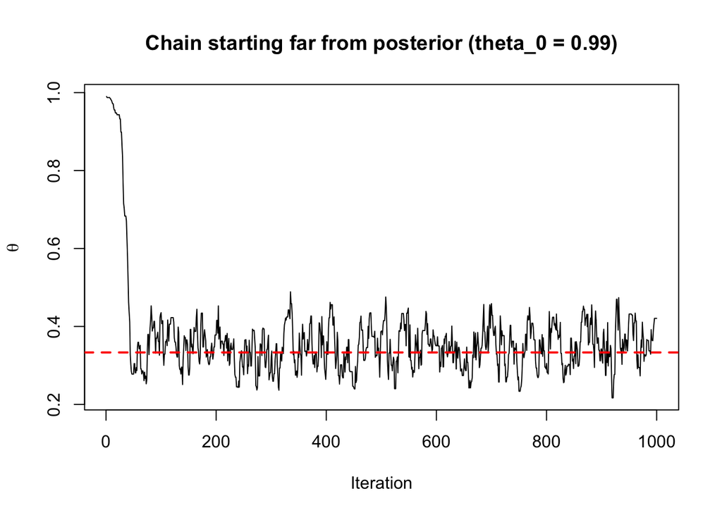

```r
theta.far <- run_metropolis(inits = 0.99, steps = 1000)

plot(theta.far, type = "l",
     xlab = "Iteration", ylab = expression(theta),
     main = "Chain starting far from posterior (theta_0 = 0.99)")
abline(h = 19/57, col = "red", lwd = 2, lty = 2)
```

**Questions:**

1. Approximately how many iterations does the chain take to “find” the posterior? This is your estimated burn-in.
2. What would happen to your posterior summaries (mean, credible interval) if you *forgot* to discard the burn-in?
3. Now run **two chains** from overdispersed starting values (e.g., 0.05 and 0.95) for 2 000 steps. Plot them together. Do they converge to the same region?

**TipHint 2a**

Look at the trace plot: identify the iteration where the chain stops trending and starts fluctuating around a stable level. Everything before that point is burn-in.

**TipHint 2b**

The burn-in samples are not from the posterior — they reflect where the chain *started*, not where it *belongs*. Including them biases all posterior summaries upward (toward the starting value of 0.99).

**TipHint 2c — Plotting two chains**

```r
theta.chain1 <- run_metropolis(inits = 0.05, steps = 2000, seed = 1)
theta.chain2 <- run_metropolis(inits = 0.95, steps = 2000, seed = 2)

plot(theta.chain1, type = "l", col = "steelblue",
     ylim = c(0, 1), xlab = "Iteration", ylab = expression(theta),
     main = "Two chains from overdispersed starts")
lines(theta.chain2, col = "coral")
abline(h = 19/57, col = "black", lwd = 2, lty = 2)
legend("topright", legend = c("Chain 1 (start = 0.05)", "Chain 2 (start = 0.95)"),
       col = c("steelblue", "coral"), lty = 1)
```

Both chains should converge to the same region — this visual check is the intuition behind the Gelman–Rubin diagnostic.

## 7 Exercise 3 — The Role of the Proposal Variance

The proposal standard deviation `away` controls how far the algorithm tries to jump at each step. It has no effect on *where* the chain converges, but a large effect on *how efficiently* it gets there.

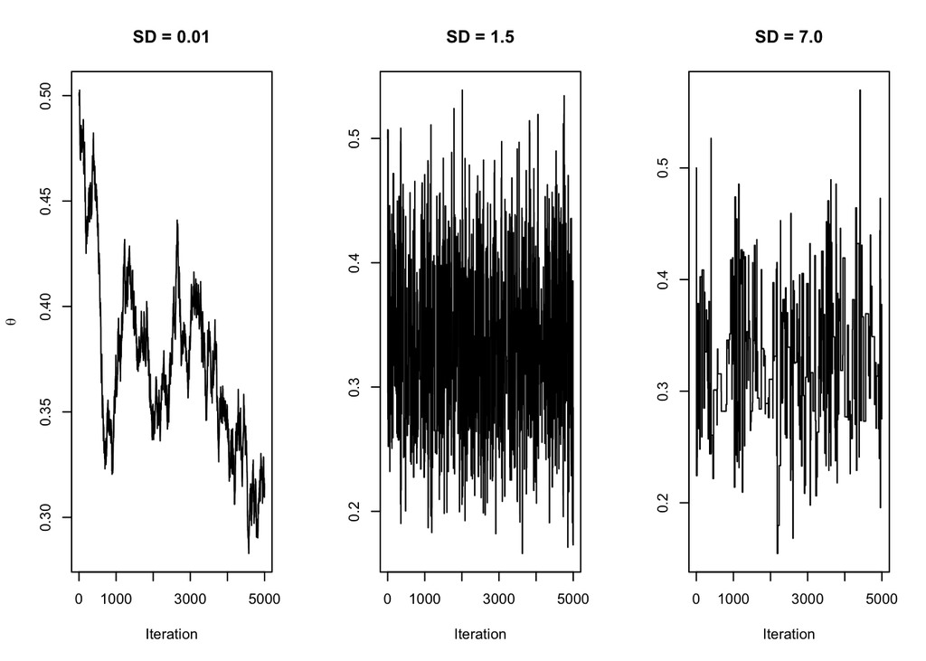

```r
theta.small  <- run_metropolis(inits = 0.5, steps = 5000, away = 0.01,  seed = 10)
theta.medium <- run_metropolis(inits = 0.5, steps = 5000, away = 1.5,   seed = 10)
theta.large  <- run_metropolis(inits = 0.5, steps = 5000, away = 7.0,   seed = 10)

par(mfrow = c(1, 3))
plot(theta.small,  type = "l", main = "SD = 0.01",  ylab = expression(theta), xlab = "Iteration")
plot(theta.medium, type = "l", main = "SD = 1.5",   ylab = "", xlab = "Iteration")
plot(theta.large,  type = "l", main = "SD = 7.0",   ylab = "", xlab = "Iteration")
```

```r
par(mfrow = c(1, 1))
```

**Questions:**

1. Describe the behaviour of each chain. What goes wrong at the extremes?
2. Compute the **acceptance rate** for each chain. A rule of thumb for single-parameter models is 23–50%. Which chain comes closest?
3. Compute the **autocorrelation function (ACF)** for each chain. Which proposal variance produces the least autocorrelated (most “independent-looking”) samples?

**TipHint 3a**

- **Too small:** the chain takes tiny steps and barely moves — it mixes slowly and gets stuck for long stretches.
- **Too large:** most proposals overshoot the posterior mass and get rejected — the chain also gets stuck, but by refusing to move rather than by moving too little.

**TipHint 3b — Acceptance rate**

The acceptance rate is the proportion of steps where the chain *moved* (i.e., consecutive values differ):

```r
acceptance_rate <- function(chain) mean(diff(chain) != 0)

acceptance_rate(theta.small)
acceptance_rate(theta.medium)
acceptance_rate(theta.large)
```

**TipHint 3c — ACF plots**

```r
par(mfrow = c(1, 3))
acf(theta.small,  main = "ACF: SD = 0.01")
acf(theta.medium, main = "ACF: SD = 1.5")
acf(theta.large,  main = "ACF: SD = 7.0")
par(mfrow = c(1, 1))
```

High autocorrelation (ACF stays near 1 for many lags) means consecutive samples are nearly identical — you need far more of them to get reliable posterior estimates.

## 8 Exercise 4 — Effective Sample Size

Because MCMC samples are **serially correlated**, 5 000 raw draws do not carry the same information as 5 000 independent draws. The **effective sample size** ($n_\text{eff}$) adjusts for this autocorrelation:

$$n_\text{eff} = \frac{n}{1 + 2\sum_{k=1}^{\infty} \hat{\rho}_k}$$

where $\hat{\rho}_k$ is the estimated autocorrelation at lag $k$. The `coda` package computes this directly.

```r
library(coda)

neff_small  <- effectiveSize(theta.small)
neff_medium <- effectiveSize(theta.medium)
neff_large  <- effectiveSize(theta.large)

data.frame(
  proposal_sd  = c(0.01, 1.5, 7.0),
  raw_samples  = 5000,
  n_eff        = round(c(neff_small, neff_medium, neff_large))
)
```

```
  proposal_sd raw_samples n_eff
1        0.01        5000     6
2        1.50        5000   810
3        7.00        5000   204
```

**Questions:**

1. Which proposal variance yields the highest $n_\text{eff}$? Does this match your expectations from Exercise 3?
2. For the poorly-mixing chains, how many *raw* samples would you need to collect to achieve the same $n_\text{eff}$ as the best chain?
3. As a general guideline, $n_\text{eff} \geq 100$ is considered the minimum for reliable posterior summaries. Which chains meet this threshold with 5 000 raw samples?

**TipHint 4a**

The chain with intermediate proposal SD should have the highest $n_\text{eff}$ — it balances exploration and acceptance, producing samples that are as close to independent as possible given the algorithm.

**TipHint 4b**

If the best chain has $n_\text{eff} = 2000$ from 5 000 samples, and a poor chain has $n_\text{eff} = 50$ from 5 000 samples, you would need approximately $5000 \times (2000 / 50) = 200\,000$ raw samples from the poor chain to match.

## 9 Exercise 5 — The Gelman–Rubin Diagnostic ($\hat{R}$)

The **Gelman–Rubin statistic** $\hat{R}$ formalises the visual check from Exercise 2. It compares **between-chain variance** to **within-chain variance** across multiple chains run from overdispersed starting points:

$$\hat{R} = \sqrt{\frac{\text{Var}_\text{between} + \text{Var}_\text{within}}{\text{Var}_\text{within}}}$$

Intuitively: if all chains have converged to the *same* distribution, between-chain variance should be negligible relative to within-chain variance, and $\hat{R} \approx 1$. The conventional threshold is $\hat{R} < 1.1$.

```r
library(coda)

# Run 4 chains from overdispersed starting values
starts <- c(0.05, 0.3, 0.7, 0.95)
chains <- lapply(seq_along(starts), function(i) {
  mcmc(run_metropolis(inits = starts[i], steps = 2000, seed = i))
})
chain_list <- mcmc.list(chains)

# Gelman-Rubin diagnostic
gelman.diag(chain_list)
```

```
Potential scale reduction factors:

     Point est. Upper C.I.
[1,]       1.01       1.03
```

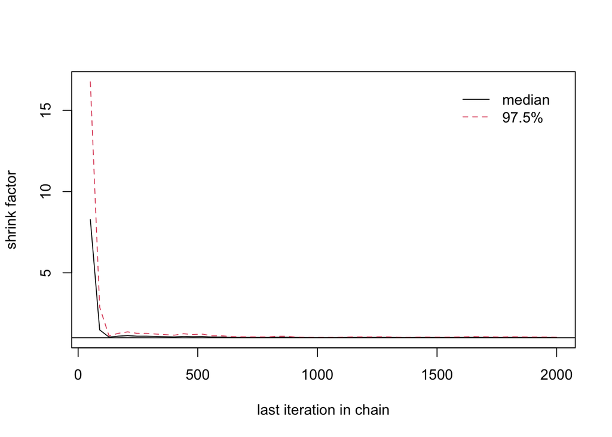

```r
gelman.plot(chain_list)
```

**Questions:**

1. At what number of iterations does $\hat{R}$ drop below 1.1? Does this match your visual estimate of burn-in from Exercise 2?
2. Re-run with only **50 steps** per chain. What happens to $\hat{R}$? What does this tell you about minimum chain length?
3. What is the conceptual difference between $\hat{R}$ and $n_\text{eff}$? What does each diagnose?

**TipHint 5a**

The `gelman.plot()` function shows $\hat{R}$ as a function of iteration. Find the first point where the line crosses 1.1 from above and stays below it.

**TipHint 5b**

With very short chains, the between-chain variance will dominate because different chains haven’t had time to explore the same region. $\hat{R}$ will be large (potentially much greater than 1.1), signalling non-convergence even if the model is correctly specified.

**TipHint 5c**

- $\hat{R}$ answers: **“Have all chains converged to the same distribution?”** — a question about *where* the chain is.
- $n_\text{eff}$ answers: **“How many independent samples do I effectively have?”** — a question about the *quality* of information in the chain.

You need both: $\hat{R}$ checks convergence, $n_\text{eff}$ checks whether you have enough post-convergence samples.

## 10 Summary

| Concept | What it measures | Target |
| --- | --- | --- |
| **Trace plot** | Visual chain behaviour | Hairy caterpillar, no trends |
| **Acceptance rate** | Fraction of proposals accepted | ~23–50% (univariate) |
| **Burn-in** | Iterations before stationarity | Discard; inspect trace plot |
| **$\hat{R}$** | Cross-chain convergence | $< 1.1$ |
| **ACF** | Serial correlation in chain | Rapid decay to zero |
| **$n_\text{eff}$** | Information-adjusted sample size | $\geq 100$ per parameter |

The core message: MCMC turns posterior inference into a simulation problem. The algorithm never needs $P(\text{data})$ — the normalising constant cancels in the acceptance ratio. What it does need is careful **tuning** (proposal variance), sufficient **warm-up** (burn-in), and proper **diagnostics** ($\hat{R}$, $n_\text{eff}$) to confirm that the samples you collect are trustworthy representations of the posterior.

## 11 Now that you have played around check out these visualizations

- **Animating the Metropolis algorithm (1D):**  
  https://gist.github.com/oliviergimenez/5ee33af9c8d947b72a39ed1764040bf3
- **Animating the Metropolis algorithm (2D):**  
  https://mbjoseph.github.io/posts/2018-12-25-animating-the-metropolis-algorithm/
- **MCMC Interactive Gallery:**  
  https://chi-feng.github.io/mcmc-demo/

## 12 References

Gimenez, O. (2025). *Bayesian statistics with R: Markov Chain Monte Carlo*. Lecture slides, November–December 2025. https://oliviergimenez.github.io/bayesian-stats-with-R/slides/mcmc.pdf